# ESM 204 HW 3

Jennifer Truong

5/8/2020

## Question 1

#### Finding Supply and Demand Curves

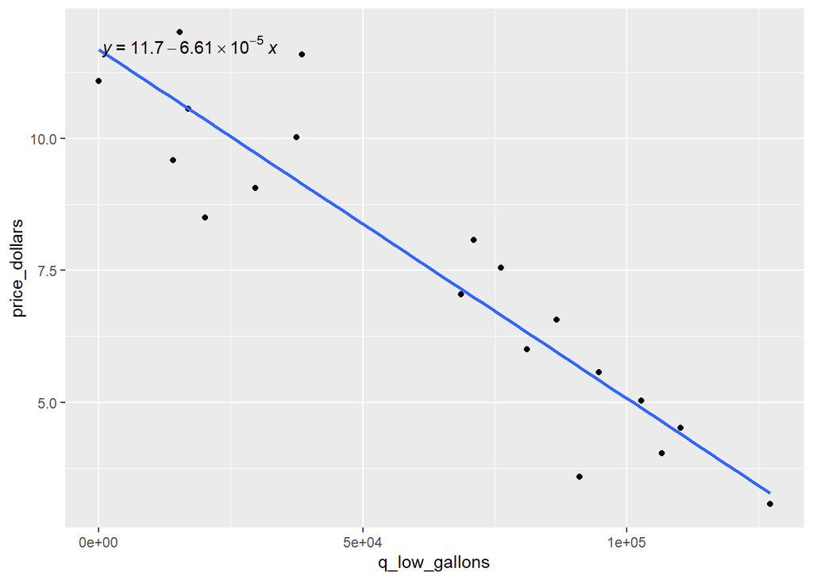

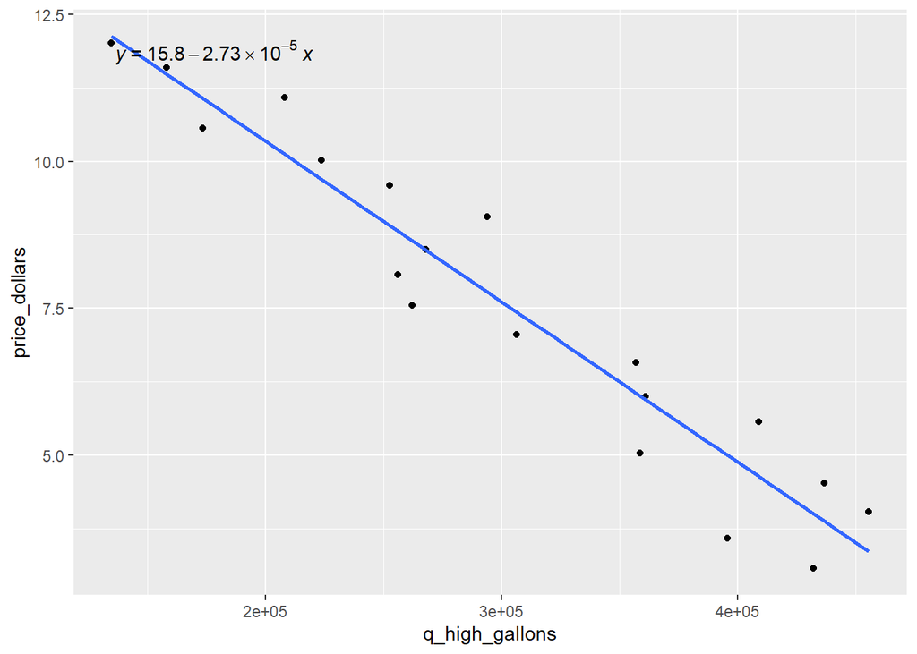

Low income demand curve: $P = 11.7 - (6.61*10^{-5})Q$

High income demand curve: $P = 15.8 - (2.73*10^{-5})Q$

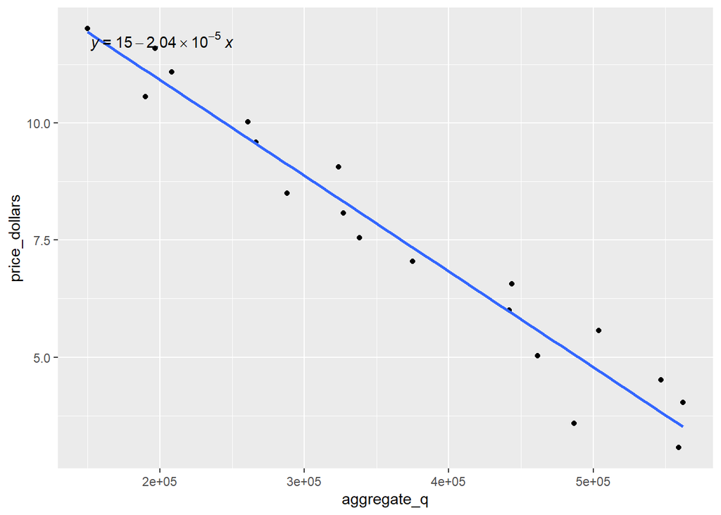

Aggregate demand curve: $P = 15 - (2.04*10^{-5})Q$

Supply curve: $P = 5.110*10^{-6}Q$

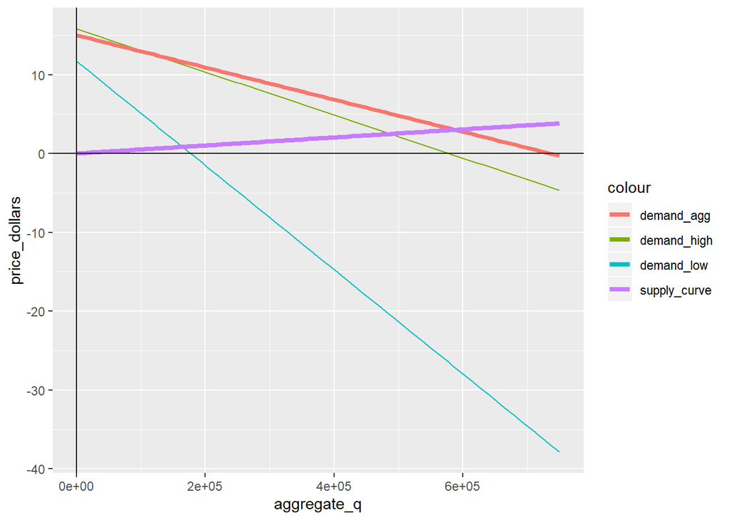

At market equilibrium, the price is 3 dollars and the quantity is 5.882352910^{5} gallons.

#### Finding benefits

- The benefit to consumers under the status quo is 3.529411810^{6}
- The benefit to producers under the status quo is 8.823529410^{5}

#### Envi Cost

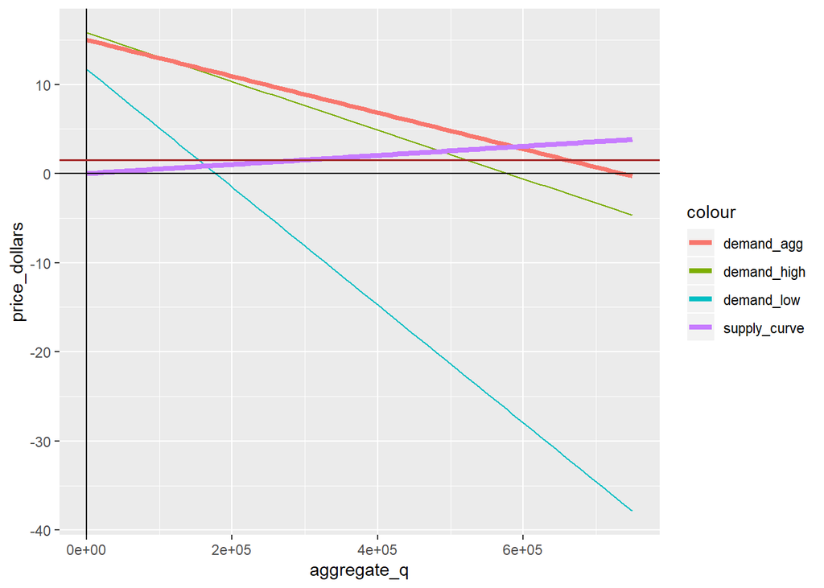

The local environmental cost under the status quo is $8.823529410^{5}

The global environmental cost under the status quo is $2.941176510^{5}

## Question 2

#### Individual CS for both Low Income and High Income

The consumer benefit for low income is 5.72541610^{5}

The consumer benefit for high income is 3.000732610^{6}

## Question 3

#### a) Effect on amount of gas produced and consumed

Supply curve after the tax: $P = (5.110*10^{-6})Q + 1.00$

It would reduce the equilibrium quantity to 5.488043910^{5} gallons, down by 6.7%.

#### b) Price on gas

It would increase the curent price from 3 to 4 dollars.

#### c) Welfare of “High” income consumers.

The tax would reduce the welfare of high income customers to 2.550183210^{6}, down by 15.01%.

#### d) Welfare of “Low” income consumers.

The tax would reduce the welfare of low income customers to 4.484871410^{5}, down by 21.67%.

#### f) Local environmental damage.

$1.50 - 1.00 = 0.50$

The tax would cover two thirds of the original local externality of 1.50, leaving $0.50 behind.

#### g) Rest of world environmental damage.

$0.50 - 1.00 = -0.50$

The tax would cover the whole climate change externality.

#### h) Total revenue generated by the tax.

The total revenue generated by the tax would be $5.488043910^{5}

## Question 5 - Electric Vehicle

#### c) Gas price

The gas price decreases to $2.5, down by 16.56%

#### d) Local environmental damage from gasoline

The local environmental cost with EV implementation is $7.348138510^{5}

#### e) Rest of world environmental damage from gasoline

The global environmental cost with EV implementation is $2.449379510^{5}

## Question 6

The tax revenue with the gas tax is $5.488043910^{5}, while the tax revenue with the electric car technology and without the tax is 2.433380910^{5}.